# Analiza Danych - Laboratorium 4

Przegląd rozkładów prawdopodobieństwa

Adrian Kowalski

Politechnika Krakowska

W tym notatniku zajmiemy się generowaniem prób z powszechnych rozkładów prawdopodobieństwa, inspekcją ich histogramów i wykresów pudełkowych. Pomoże to nam w przyszłości w wysuwaniu hipotez i podejmowaniu odpowiednich kroków przy analizie szczególnych typów danych. W dalszej części notanika przez $X$ oznaczamy zmienną losową o rozkładzie rozważanym w obecnym rozdziale, przez $A$ dowolny podzbiór $\mathbb{R}$.

# Rozkład jednopunktowy

Rozkład jednopunktowy skupiony w punkcie $a$ jest najbardziej trywialnym przypadkiem dyskretnego rozkładu prawdopodobieństwa. Jego PMF (Probability Mass Function) dana jest wzorem

$$P(X \in A) = \delta_a(A) = \left\{
\begin{array}{ll} 1 & a \in A, \\ 0 & a \notin A. \end{array}
\right.$$

Innymi słowy
$$P(X = a) = 1.$$

Łatwo wywnioskować, że dystrybuanta takiego rozkładu ma postać
$$F(x) = \left\{ \begin{array}{ll} 1 & x >=
a, \\ 0 & x < a. \end{array} \right.$$

### Zadanie

“Wygeneruj” próbę z rozkładu jednopunktowego, narysuj jej funkcję masy, histogram, wykres pudełkowy oraz dystrybuantę.

# Rozkład dwupunktowy

Średnia i wariancja tego rozkładu to
$$\mathbb{E}X = p, \, \mathbb{D}^2X = p(1-p).$$

Uwaga: Naturalnym uogólnieniem tej konstrukcji jest rozkład $n$-punktowy, który jest kombinacją wypukłą $n$ rozkładów jednopunktowych skupionych w $n$ różnych punktach.

Do generowania próby z rozkładu dwupunktowego skupionego w punktach $0,1$ w **R** służy nam funkcja *rbinom()* z parameterem $size=1$.

```r
coin_toss <- rbinom(n=100, size=1, prob=0.5)
coin_toss
```

```
##   [1] 1 0 1 0 0 1 0 0 1 0 0 1 1 0 1 1 0 1 0 1 1 1 0 0 1 0 1 1 0 1 1 1 0 1 1 1 0
##  [38] 1 1 0 1 0 0 0 0 1 0 0 0 1 0 0 1 0 1 1 0 1 1 1 0 1 1 1 1 0 0 0 1 1 0 0 1 0
##  [75] 0 0 0 0 1 1 1 1 0 0 1 1 0 1 0 1 0 1 1 1 1 1 0 0 1 1
```

```r
coin_toss_table <- as_tibble(coin_toss) %>% group_by(value) %>% count() %>% mutate(n = n/length(coin_toss))
coin_toss_table
```

| value | n |
| --- | --- |
| 0 | 0.46 |
| 1 | 0.54 |

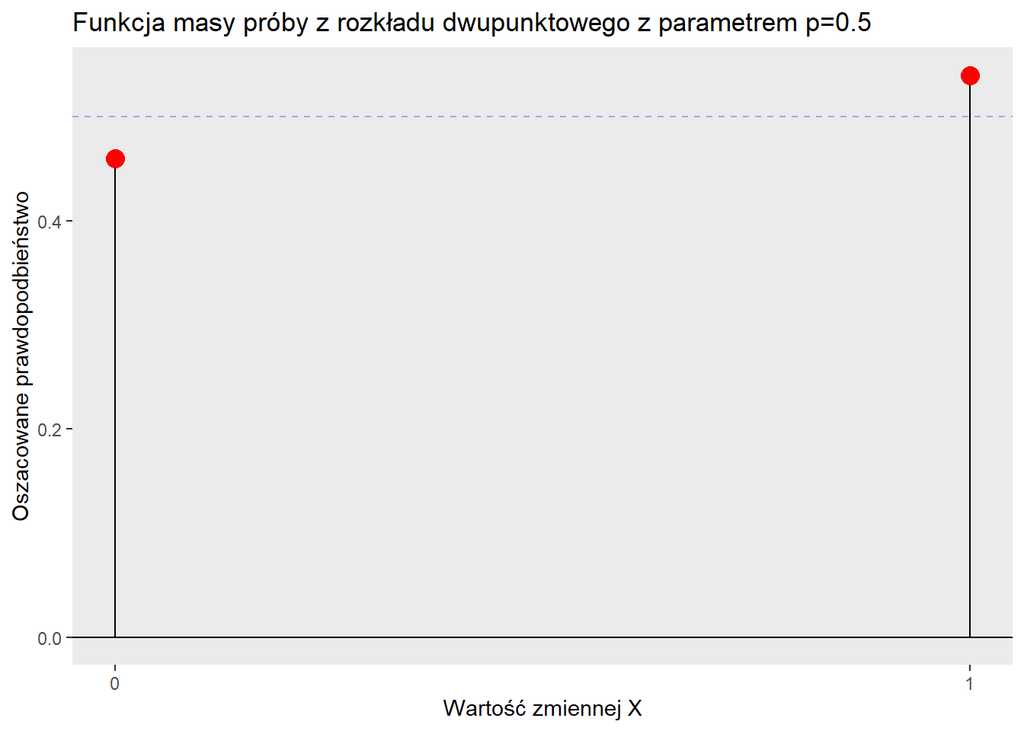

```r
coin_toss_mass
```

Równie dobrze mogliśmy wyrysować funkcję masy tego rozkładu za pomocą *dbinom()*.

```r
binom_mass <- tibble(point = c(0,1)) %>% mutate(mass = dbinom(point, size=1, prob=0.5))
binom_mass
```

| point | mass |
| --- | --- |
| 0 | 0.5 |
| 1 | 0.5 |

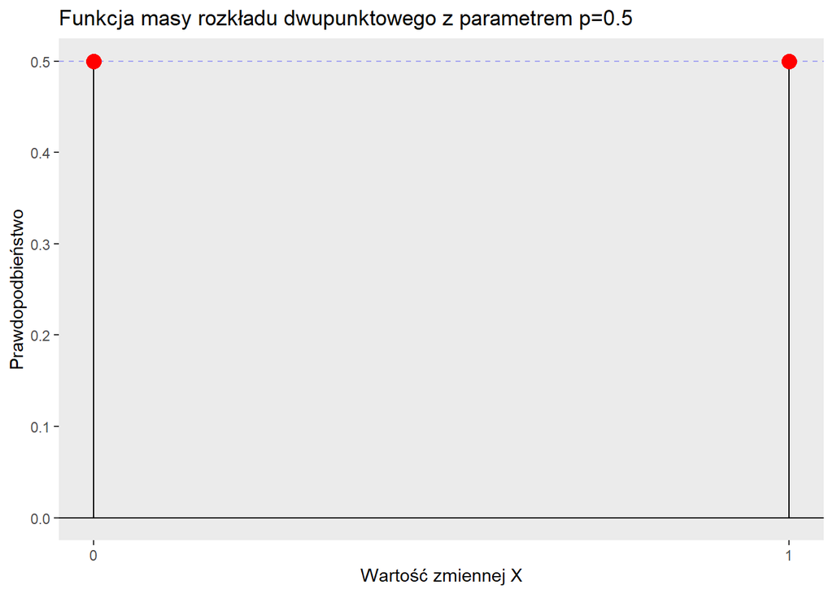

```r
binom_mass
```

Dystrybuantę otrzymujemy za pomocą polecenia *pbinom()*.

```r
binom_cdf <- tibble(points=seq(-2,2,0.25)) %>% mutate(cdf = pbinom(points, size=1, prob=0.5))
binom_cdf
```

| points | cdf |
| --- | --- |
| -2.00 | 0.0 |
| -1.75 | 0.0 |
| -1.50 | 0.0 |
| -1.25 | 0.0 |
| -1.00 | 0.0 |
| -0.75 | 0.0 |
| -0.50 | 0.0 |
| -0.25 | 0.0 |
| 0.00 | 0.5 |
| 0.25 | 0.5 |

[output cut: 7 more lines]

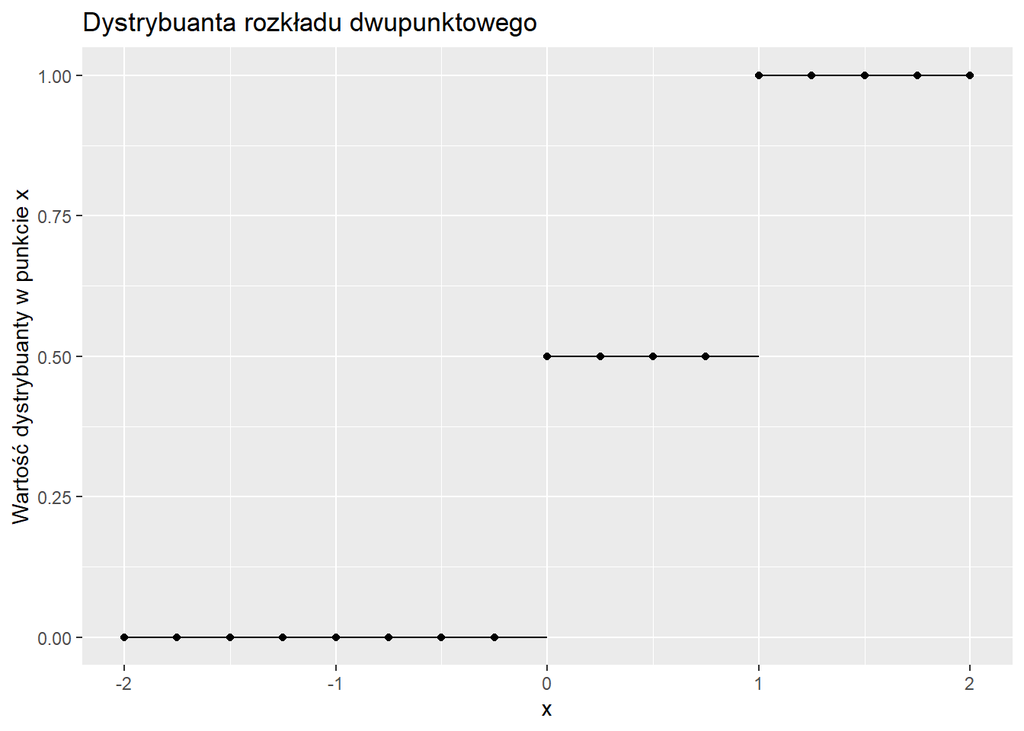

```r
binom_cdf_plot
```

# Rozkład dwumianowy (Bernouliego)

Pewnego rodzaju uogólnieniem rozkładu dwupunktowego jest rozkład dwumianowy z parametrami $n \in \mathbb{N}, p \in [0,1]$. PMF takiego rozkładu wyraża się wzorem
$$P(X = k) = \left( \begin{array}{c} n \\
k\end{array} \right)p^k (1-p)^{n-k}.$$

Średnia i wariancja tego rozkładu to
$$\mathbb{E}X = np, \, \mathbb{D}^2X = np(1-p).$$

Do generownania próby z rozkładu dwumianowego używamy nadal funkcji *rbinom()*, tym razem z parametrem *size = n*.

```r
bernouli_sample <-  as_tibble(rbinom(100, 5, p=0.5))
bernouli_sample
```

| value |
| --- |
| 1 |
| 1 |
| 1 |
| 3 |
| 3 |
| 2 |
| 4 |
| 2 |
| 3 |
| 4 |

[output cut: 90 more lines]

Ponownie zobaczmy jak wygląda masa z naszej próby.

```r
bernouli_mass <- as_tibble(bernouli_sample) %>% group_by(value) %>% count() %>% mutate(n = n/length(bernouli_sample))
```

```r
bernouli_mass
```

| value | n |
| --- | --- |
| 0 | 4 |
| 1 | 13 |
| 2 | 26 |
| 3 | 42 |
| 4 | 13 |
| 5 | 2 |

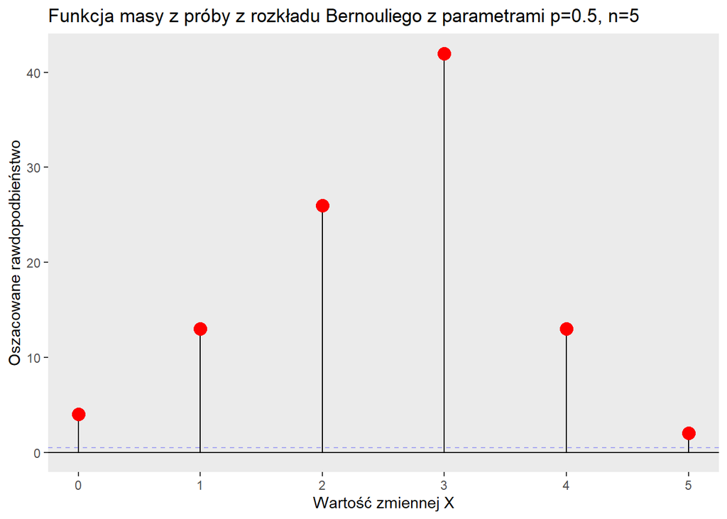

```r
bernouli_mass_plot
```

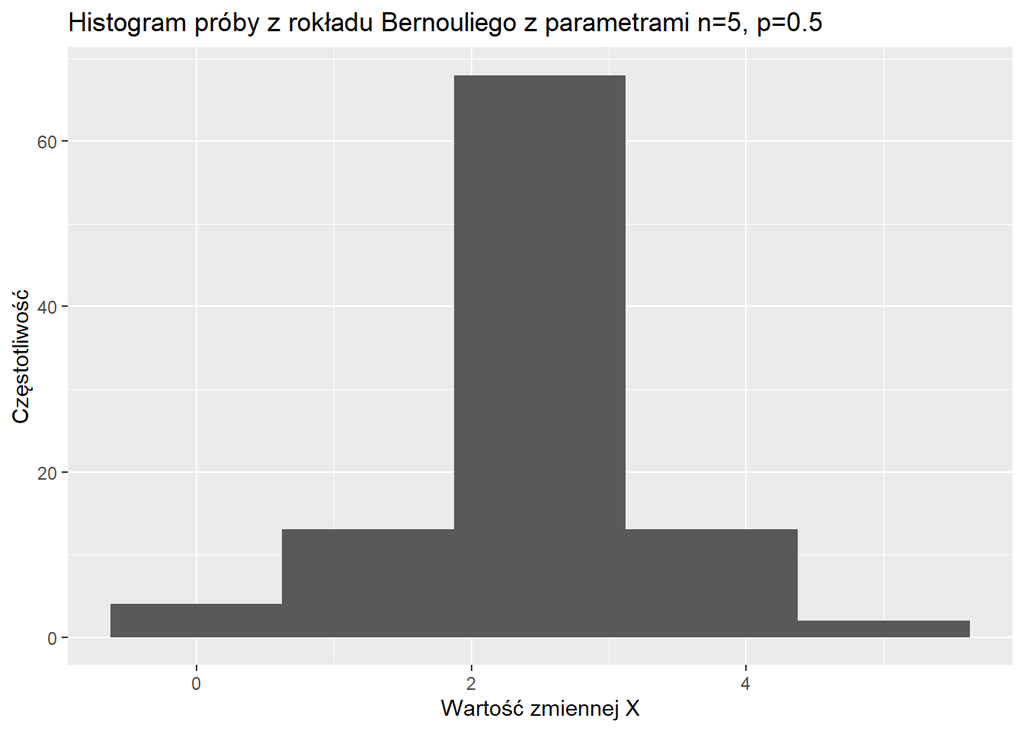

```r
bernouli_hist
```

```r
bernouli_sample2 <- as_tibble(rbinom(100, size=40, p=0.5))
bernouli_sample2
```

| value |
| --- |
| 22 |
| 20 |
| 18 |
| 17 |
| 21 |
| 16 |
| 18 |
| 20 |
| 22 |
| 23 |

[output cut: 90 more lines]

[figure not shown]

```r
bernouli_mass_plot2
```

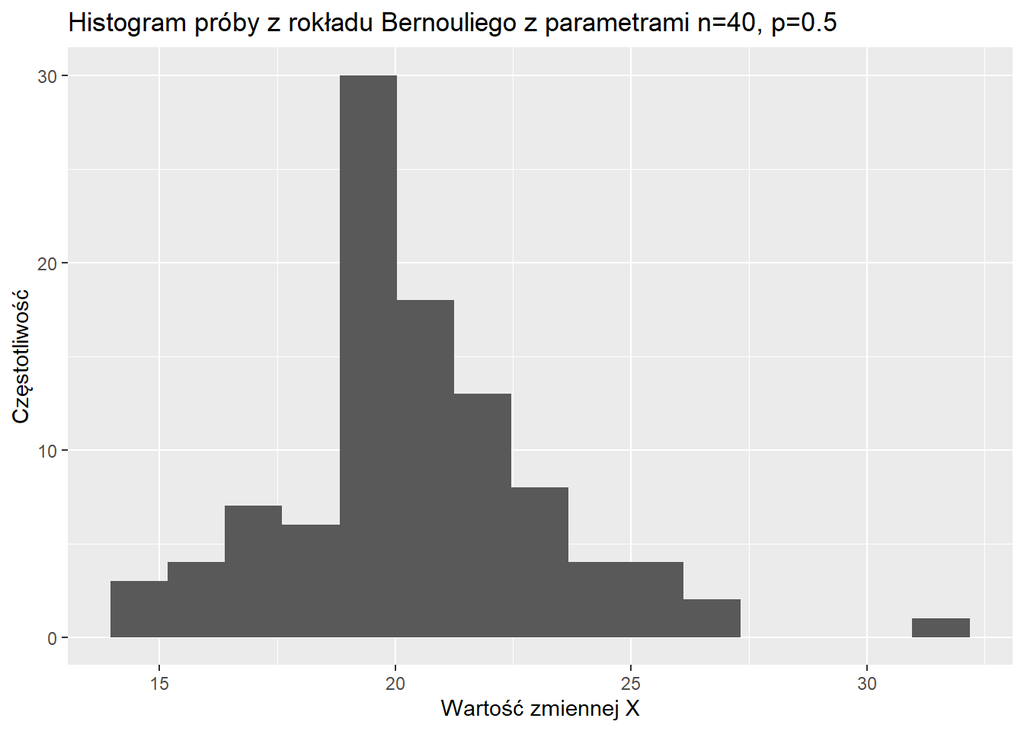

```r
bernouli_hist2
```

#### Ćwiczenie

# Rozkład Poissona

Kolejnym rozkłądem, który rozważymy jest rozkład Poissona z paramterem $\lambda \in (0, \infty)$. Jego funkcja masy wyraża się wzorem

$$P(X = k) = \frac{\lambda^k}{k!}
e^{-\lambda}.$$

Średnia i wariancja tego rozkładu są równe

$$\mathbb{E}X = \lambda, \, \mathbb{D}^2
X = \lambda.$$

Z rozkładem Poissona jest powiązane tzw. prawo małych liczb.

Twierdzenie. Rozważmy liczby $n \in \mathbb{N}, p_n \in (0,1)$, takie że $lim_{n \rightarrow \infty} np_n = \lambda$ dla pewnej liczby $\lambda \in (0, \infty)$. Wówczas
$$lim_{n
\rightarrow \infty} \left( \begin{array}{cc} n \\ k \end{array} \right)
p_n^k (1-p_n)^{(n-k)} = e^{-\lambda} \frac{\lambda^k}{k!}.$$

Uwaga: W praktyce powyższe twierdzenie jest “efektywne” dla $n\geq 20, p < 0.05$ oraz $n \geq 100, np \leq 10$.

#### Ćwiczenie

1.Wygeneruj próbę z rozkładu Poissona za pomocą *rpois()*, narysuj gęstość tej próby i histogram.

2.Zweryfikuj powyższe prawo małych liczb empirycznie, generując próby z odpowiednich rozkładów bernouliego i poissona i porównując gęstości, histogramy, statystyki opisowe.

# Rozkład jednostajny

Rozkład jednostajny z parametrami $a,b, \, b>a$ jest najprostszym przykładem rozkładu ciągłego. Jego gęstość wyraża się wzorem

$$f(x) = \left\{ \begin{array}{ll}
\frac{1}{b-a}, & x \in [a,b], \\ 0, & x \notin [a,b].
\end{array} \right.$$

Uwaga: Szczególnie ważnym przypadkiem jest rozkład o parametrach $a=0, b=1$.

Dystrybuanta takiego rozkładu dana jest wzorem

$$F(x) = \left\{ \begin{array}{ll} 0,
& x < a, \\ \frac{x}{b-a}, & a \leq x < b, \\ 1, & b
\leq x. \end{array} \right.$$

Próbę z rozkładu jednostajnego generujemy za pomocą funkcji *runif()*.

```r
uniform_sample <- as_tibble(runif(100))
uniform_sample
```

| value |
| --- |
| 0.05720164 |
| 0.53915024 |
| 0.76704209 |
| 0.81473169 |
| 0.05285093 |
| 0.53392360 |
| 0.81958423 |
| 0.93892987 |
| 0.47912905 |
| 0.83384813 |

[output cut: 90 more lines]

#### Ćwiczenie

1. Narysuj gęśtość i histogram powyższej próby. Narysuj również gęstość otrzymaną za pomocą funkcji *dunif()*.
2. Narysuj dystrybuantę empiryczną i taką otrzymaną za pomocą funkcji *punif()*.

# Rozkład wykładniczy

Rozkład wykładniczy z parameterem $\lambda \in (0, \infty)$ to ciągły odpowiednik rozkładu geometrycznego. Gęstość tego rozkładu wyraża się wzorem
$$f(x) = \mathbf{1}_{[0,\infty)}(x) \lambda e^{-\lambda x}.$$

Dystrybuanta dana jest wzorem

$$F(x) = \left\{ \begin{array}{ll} 0,
& x < 0, \\ 1 - e^{-\lambda x}, & x \geq 0. \end{array}
\right.$$

Średnia i wariancja mają postać
$$\mathbb{E}X = \frac{1}{\lambda}, \, \mathbb{D}^2X = \frac{1}{\lambda^2}.$$

Próbę z rozkładu wykładniczego generujemy za pomocą funkcji *rexp()*.

#### Ćwiczenie

1. Wygeneruj próby z rozkładu wykładniczego dla różnych $\lambda$, narysuj ich gęstości na jednym obrazku dla porównania.
2. Narysuj dystrybuantę rozkładu wykładniczego za pomocą funckji *pexp()*.

# Rozkład normalny

Skupimy swoją uwagę na rozkładzie normalnym już na następnych zajęciach :)